# Assess somatic CNV and LOH second hits

Ryan Corbett

This analysis identifies patients with germline P/LP variants in cancer predisposition genes that show subsequent seconds CNV or loss of heterozygosity (LOH) hits in tumors

Set libraries and file paths

```r
# load libraries
library(tidyverse)
library(ggplot2)
library(ggpubr)

# define directories
root_dir <- rprojroot::find_root(rprojroot::has_dir(".git"))
analysis_dir <- file.path(root_dir, "analyses", "two-hits")
results_dir <- file.path(analysis_dir, "results")
plot_dir <- file.path(analysis_dir, "plots")
data_dir <- file.path(root_dir, "data")

# If the input and results directories do not exist, create it
if (!dir.exists(results_dir)) {
  dir.create(results_dir, recursive = TRUE)
}

source(file.path(root_dir, "figures", "theme.R"))
source(file.path(analysis_dir, "util", "cnv_loh_functions.R"))
```

Define file paths

```r
# germline P/LP calls
plp_file <- file.path(data_dir,
                      "pbta-merged-plp-variants-autogvp-abridged.tsv")

plp_lowVAF_file <- file.path(data_dir,
                             "pbta-merged-plp-variants-autogvp-abridged-lowVAF-cpgs.tsv")

plp_sv_file <- file.path(data_dir,
                         "pbta_germline_svs.tsv")

# add histologies file
histologies_file <- file.path(root_dir, "analyses",
                                  "collapse-tumor-histologies", "results",
                                  "germline-primary-plus-tumor-histologies-plot-groups-clin-meta.tsv")

# cnv file with annotation
cnv_auto_file <- file.path(data_dir, "consensus_seg_annotated_cn_autosomes.tsv.gz")
cnv_xy_file <- file.path(data_dir, "consensus_seg_annotated_cn_x_and_y.tsv.gz")

# LOH variant and gene files
loh_variant_file <- file.path(data_dir, "pbta-plp-all-loh.tsv")
loh_gene_file <- file.path(data_dir, "pbta-all-gene-loh.tsv.gz")

cnvkit_file <- file.path(data_dir, "cnv-cnvkit-cns.tsv.gz")

# cpg file
cpg_file <- file.path(root_dir, "analyses", "oncokb-annotation", "input", "cpg.txt")
hgat_file <- file.path(root_dir, "analyses", "variant-distribution", "input", "hgat_goi_list.tsv")
lgat_file <- file.path(root_dir, "analyses", "variant-distribution", "input", "lgat_goi_list.tsv")
embryonal_file <- file.path(root_dir, "analyses", "variant-distribution", "input", "embryonal-tumor_goi_list.tsv")
other_file <- file.path(root_dir, "analyses", "variant-distribution", "input", "other_goi_list.tsv")
```

Read in PLP, histology, and cpg files. Subset P/LP calls to CPGs only and add histology

```r
hist <- read_tsv(histologies_file)
# Load abridged P/LP file and append variant coordinates
germline <- read_tsv(plp_file) %>%
  bind_rows(read_tsv(plp_lowVAF_file)) %>%
  dplyr::rename(Hugo_Symbol = gene_symbol_vep) %>%
  filter(Kids_First_Biospecimen_ID_normal %in% hist$Kids_First_Biospecimen_ID_normal)
germline_sv <- read_tsv(plp_sv_file) %>%
  dplyr::rename(Hugo_Symbol = Hugo_Symbol_cpg) %>%
  filter(Kids_First_Biospecimen_ID_normal %in% hist$Kids_First_Biospecimen_ID_normal)
# CPGs
cpgs <- read_lines(cpg_file)
hgat_drivers <- read_lines(hgat_file)
lgat_drivers <- read_lines(lgat_file)
embryonal_drivers <- read_lines(embryonal_file)
other_drivers <- read_lines(other_file)
somatic_drivers <- c(hgat_drivers, lgat_drivers, embryonal_drivers, other_drivers)

# filter PLP calls for cpgs, and add plot_group and molecular_subtype
germline <- germline %>%
  filter(Hugo_Symbol %in% c(cpgs, somatic_drivers)) %>%
  left_join(hist[,c("Kids_First_Participant_ID", "Kids_First_Biospecimen_ID_normal",
                          "Kids_First_Biospecimen_ID_tumor",
                          "plot_group", "molecular_subtype")],
            by = "Kids_First_Biospecimen_ID_normal") %>%
  dplyr::select(Kids_First_Biospecimen_ID_normal, Kids_First_Participant_ID,
                Kids_First_Biospecimen_ID_tumor,
                plot_group, molecular_subtype,
                Hugo_Symbol, autogvp_call, autogvp_call_reason,
                chr, start, ref, alt, HGVSc, HGVSp) %>%
  distinct(Kids_First_Biospecimen_ID_normal, Kids_First_Biospecimen_ID_tumor, Hugo_Symbol, start, .keep_all = T) %>%
  dplyr::mutate(sample_variant_coord = glue::glue("{Kids_First_Biospecimen_ID_normal}:{chr}:{start}"))

germline_sv <- germline_sv %>%
  left_join(hist[,c("Kids_First_Participant_ID", "Kids_First_Biospecimen_ID_normal",
                          "Kids_First_Biospecimen_ID_tumor",
                          "plot_group", "molecular_subtype")],
            by = "Kids_First_Biospecimen_ID_normal") %>%
  dplyr::select(Kids_First_Biospecimen_ID_normal, Kids_First_Participant_ID,
                Kids_First_Biospecimen_ID_tumor,
                plot_group, molecular_subtype,
                Hugo_Symbol, Chromosome, Start, End, Length,
                Type, Classification) %>%
  distinct(Kids_First_Biospecimen_ID_normal, Kids_First_Biospecimen_ID_tumor, Hugo_Symbol, .keep_all = T)
```

Load CNV files, and identify patients with germline PLP variant and somatic CNV in same CPG

```r
# filter cnv to patients in cohort and CPG calls only
cnv_auto <- read_tsv(cnv_auto_file) %>%
  dplyr::filter(biospecimen_id %in% germline$Kids_First_Biospecimen_ID_tumor & gene_symbol %in% c(cpgs, somatic_drivers)) %>%
  dplyr::rename("Hugo_Symbol" = gene_symbol,
         "Kids_First_Biospecimen_ID_tumor" = biospecimen_id,
         "CNV_status_somatic" = status,
         "copy_number_somatic" = copy_number,
         "ploidy_somatic" = "ploidy") %>%
  dplyr::select(Hugo_Symbol, Kids_First_Biospecimen_ID_tumor,
         CNV_status_somatic)
```

```
Multiple files in zip: reading 'consensus_seg_annotated_cn_autosomes.tsv'Rows: 3917000 Columns: 7── Column specification ───────────────────────────────────────────────────────────────────────────────────────────────────────────────────────────────────────────────────────────────────────────────────…
```

```r
cnv_xy <- read_tsv(cnv_xy_file) %>%
  dplyr::filter(biospecimen_id %in% germline$Kids_First_Biospecimen_ID_tumor & gene_symbol %in% c(cpgs, somatic_drivers)) %>%
  dplyr::rename("Hugo_Symbol" = gene_symbol,
         "Kids_First_Biospecimen_ID_tumor" = biospecimen_id,
         "CNV_status_somatic" = status,
         "copy_number_somatic" = copy_number,
         "ploidy_somatic" = "ploidy") %>%
  dplyr::select(Hugo_Symbol, Kids_First_Biospecimen_ID_tumor,
         CNV_status_somatic)
```

```
Multiple files in zip: reading 'consensus_seg_annotated_cn_x_and_y.tsv'Rows: 285441 Columns: 8── Column specification ──────────────────────────────────────────────────────────────────────────────────────────────────────────────────────────────────────────────────────────────────────────────────────…
```

```r
# merge cnv tables
cnv <- cnv_auto %>%
  bind_rows(cnv_xy) %>%
  dplyr::filter(Kids_First_Biospecimen_ID_tumor %in% hist$Kids_First_Biospecimen_ID_tumor)

# merge germline SNV and somatic CNV calls by bs and gene id
germline_somatic_cnvs <- germline %>%
  left_join(cnv, by = c("Kids_First_Biospecimen_ID_tumor", "Hugo_Symbol")) %>%
  dplyr::mutate(CNV_status_somatic = case_when(
    is.na(CNV_status_somatic) ~ "neutral",
    TRUE ~ CNV_status_somatic
  )) %>%
  distinct()
germline_sv_somatic_cnvs <- germline_sv %>%
  left_join(cnv, by = c("Kids_First_Biospecimen_ID_tumor", "Hugo_Symbol")) %>%
  dplyr::mutate(CNV_status_somatic = case_when(
    is.na(CNV_status_somatic) ~ "neutral",
    TRUE ~ CNV_status_somatic
  )) %>%
  distinct()
```

Load LOH results and filter germline variants based on presence in tumor. Save these to output for other second-hit analyses

```r
loh <- read_tsv(loh_variant_file) %>%
  dplyr::rename(Kids_First_Biospecimen_ID_normal = BS_ID,
                Kids_First_Biospecimen_ID_tumor = BS_ID_tumor,
                Hugo_Symbol = gene) %>%
  dplyr::mutate(sample_variant_coord = glue::glue("{Kids_First_Biospecimen_ID_normal}:{chr}:{start}")) %>%
  dplyr::filter(sample_variant_coord %in% germline$sample_variant_coord,
                !is.na(proband_tumor_vaf),
                Kids_First_Biospecimen_ID_tumor %in% hist$Kids_First_Biospecimen_ID_tumor)
germline_in_tumor <- germline %>%
  dplyr::filter(sample_variant_coord %in% loh$sample_variant_coord | Hugo_Symbol %in% somatic_drivers[!somatic_drivers %in% cpgs]) %>%
  write_tsv(file.path(results_dir,
                      "germline-plp-variants-cpg-somatic-driver-in-tumor.tsv"))

nrow(germline_in_tumor)
```

```
[1] 218
```

Calculate LOH odds ratios and significance

```r
loh <- loh %>%
  dplyr::mutate(loh_score = proband_tumor_vaf - proband_germline_vaf,
                loh_OR = 0,
                loh_pvalue = 0) %>%
  distinct(Kids_First_Biospecimen_ID_normal, Hugo_Symbol, start, Kids_First_Biospecimen_ID_tumor,
           .keep_all = TRUE)

# Calculate LOH OR and corresponding p-values
for (i in 1:nrow(loh)){

  germline_ref_count <- loh$proband_germline_ref_depth[i]
  germline_alt_count <- loh$proband_germline_alt_depth[i]
  tumor_ref_count <- loh$proband_tumor_depth[i] - loh$proband_tumor_alt_depth[i]
  tumor_alt_count <- loh$proband_tumor_alt_depth[i]

  mat <- matrix(c(germline_ref_count, germline_alt_count,
                  tumor_ref_count, tumor_alt_count),
                2,2)

  loh$loh_OR[i] <- fisher.test(mat)$estimate
  loh$loh_pvalue[i] <- fisher.test(mat)$p.value

}
```

Load CNVkit data and add to LOH df

```r
cnvkit <- read_tsv(cnvkit_file) %>%
  dplyr::filter(ID %in% hist$Kids_First_Biospecimen_ID_tumor)
loh <- add_cnvkit(loh, cnvkit)

# add LOH_status column indicating LOH as measured by VAF or CNVKit
loh <- loh %>%
  dplyr::mutate(loh_status = case_when(
    (loh_pvalue < 0.05 & (proband_tumor_vaf >= 0.75 | proband_tumor_vaf < 0.25)) & (cnvkit_cn2 == 0 & cnvkit_cn1 != 0 ) ~ "LOH-CNVKit & VAF",
    loh_pvalue < 0.05 & (proband_tumor_vaf >= 0.75 | proband_tumor_vaf < 0.25) ~ "LOH-VAF",
    cnvkit_cn2 == 0 & cnvkit_cn1 != 0 ~ "LOH-CNVKit",
    TRUE ~ "No LOH"
  )) %>%
  arrange(Kids_First_Biospecimen_ID_normal) %>%
  write_tsv(file.path(results_dir,
                "pbta-loh-sig-calculated.tsv"))
```

Plot tumor VAF vs germline VAF

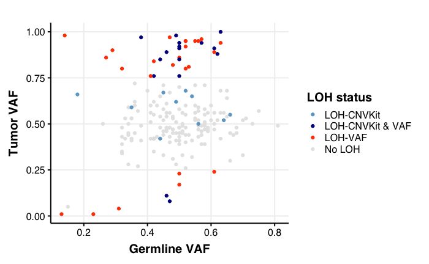

```r
loh %>%
  ggplot(aes(x = proband_germline_vaf, y = proband_tumor_vaf,
                colour = loh_status)) +
  geom_point() +
  labs(x = "Germline VAF",
       y = "Tumor VAF", color = "LOH status") +
  scale_color_manual(values = c("LOH-VAF" = "orangered", "No LOH" = "gray90",
                                "LOH-CNVKit" = "skyblue3", "LOH-CNVKit & VAF" = "darkblue")) +
  theme_Publication()

ggsave(file.path(plot_dir, "tumor-vaf-vs-germline-vaf.pdf"),
       width = 5, height = 4, units = "in")
```

Append somatic LOH results for germline variants

```r
germline_somatic_cnvs_loh <- germline_somatic_cnvs %>%
  left_join(loh[,c("Kids_First_Biospecimen_ID_tumor",
                   "chr", "start", "proband_germline_vaf", "proband_tumor_vaf",
                   "loh_score", "loh_OR", "loh_pvalue", "cnvkit_log2", "cnvkit_cn",
                   "cnvkit_cn1", "cnvkit_cn2", "loh_status")],
            by = c("Kids_First_Biospecimen_ID_tumor", "chr", "start")) %>%
  distinct()
```

Load gene LOH data and append to `germline_somatic_cnvs_loh`

```r
loh_gene <- read_tsv(loh_gene_file) %>%
  dplyr::rename(Kids_First_Biospecimen_ID_normal = BS_ID,
                Kids_First_Biospecimen_ID_tumor = BS_ID_tumor,
                Hugo_Symbol = gene,
                gene_LOH = mean_LOH_score) %>%
  dplyr::filter(Hugo_Symbol %in% c(cpgs, somatic_drivers)) %>%
  dplyr::select(Kids_First_Biospecimen_ID_normal, Kids_First_Biospecimen_ID_tumor, Hugo_Symbol,
         gene_LOH) %>%
  dplyr::filter(Kids_First_Biospecimen_ID_tumor %in% hist$Kids_First_Biospecimen_ID_tumor)
germline_somatic_cnvs_loh_gene <- germline_somatic_cnvs_loh %>%
  left_join(loh_gene)
germline_sv_somatic_cnvs_loh_gene <- germline_sv_somatic_cnvs %>%
  left_join(loh_gene) %>%
  dplyr::rename(chr = Chromosome,
                start = Start)
germline_sv_somatic_cnvs_loh_gene <- add_cnvkit(germline_sv_somatic_cnvs_loh_gene,
                                                cnvkit)

germline_sv_somatic_cnvs_loh_gene <- germline_sv_somatic_cnvs_loh_gene %>%
  dplyr::mutate(loh_status = case_when(
    gene_LOH >= 0.25 | (cnvkit_cn2 == 0 & cnvkit_cn1 != 0) ~ "LOH",
    TRUE ~ "No LOH"
  ))
```

Save CNV and LOH scores for all samples to output

```r
germline_somatic_cnvs_loh_gene %>%
  dplyr::filter(Hugo_Symbol %in% cpgs) %>%
  arrange(Kids_First_Biospecimen_ID_normal) %>%
  distinct() %>%
  write_tsv(file.path(results_dir, "germline-somatic-cnv-loh-cpgs.tsv"))

germline_somatic_cnvs_loh_gene %>%
  dplyr::filter(!Hugo_Symbol %in% cpgs) %>%
  arrange(Kids_First_Biospecimen_ID_normal) %>%
  distinct() %>%
  write_tsv(file.path(results_dir, "germline-somatic-cnv-loh-somatic-non-cpgs.tsv"))

germline_sv_somatic_cnvs_loh_gene %>%
  arrange(Kids_First_Biospecimen_ID_normal) %>%
  write_tsv(file.path(results_dir, "germline-sv-somatic-cnv-loh-somatic-cpgs.tsv"))
```

Create df to plot LOH by CNV status

```r
cnv_loh_plot_df <- germline_somatic_cnvs_loh_gene %>%
  dplyr::filter(Kids_First_Biospecimen_ID_tumor %in% hist$Kids_First_Biospecimen_ID_tumor,
                Hugo_Symbol %in% cpgs) %>%
  dplyr::select(Kids_First_Biospecimen_ID_normal, Hugo_Symbol,
                CNV_status_somatic, loh_score, gene_LOH) %>%
  bind_rows(germline_sv_somatic_cnvs_loh_gene %>%
              dplyr::select(Kids_First_Biospecimen_ID_normal, Hugo_Symbol,
                CNV_status_somatic, gene_LOH)) %>%
  distinct(Kids_First_Biospecimen_ID_normal, Hugo_Symbol, .keep_all = TRUE) %>%
  dplyr::mutate(CNV_status_somatic = fct_relevel(CNV_status_somatic,
                                                 c("gain", "neutral", "loss")))
```

Plot variant LOH by CNV status

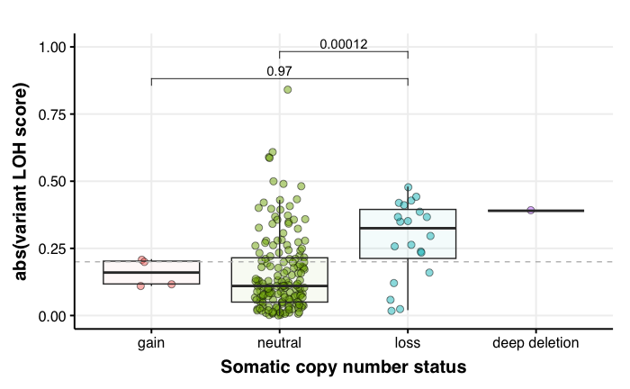

```r
cnv_loh_plot_df %>%
  ggplot(aes(x = CNV_status_somatic, y = abs(loh_score),
              fill = CNV_status_somatic)) +
  geom_jitter(shape = 21, width = 0.2, size = 2.5, alpha = 0.5,
              show.legend = FALSE) +
  geom_boxplot(alpha = 0.05, outlier.shape = NA,
                 show.legend = FALSE) +
  stat_compare_means(method = "wilcox",
                     comparisons = list(c("gain", "loss"),
                                        c("loss", "neutral"),
                                        c("gain", "neutral")),
                     method.args = list(alternative = "greater")) +
  geom_hline(yintercept = 0.2, linetype = "dashed", color = "gray") +
  labs(x = "Somatic copy number status", y = "abs(variant LOH score)", color = "Histology") +
  ylim(c(0,1)) +
  theme_Publication()

  ggsave(file.path(plot_dir, "variant-LOH-by-cnv-status.pdf"),
                 width = 6, height = 4)
```

Plot gene LOH by CNV status

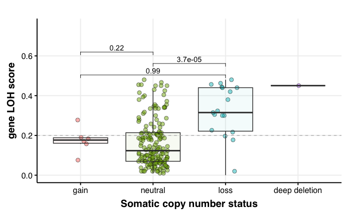

```r
cnv_loh_plot_df %>%
  ggplot(aes(x = CNV_status_somatic, y = abs(gene_LOH),
              fill = CNV_status_somatic)) +
  geom_jitter(shape = 21, width = 0.2, size = 2.5, alpha = 0.5,
              show.legend = FALSE) +
  geom_boxplot(alpha = 0.05, outlier.shape = NA,
                 show.legend = FALSE) +
  stat_compare_means(method = "wilcox",
                     comparisons = list(c("gain", "loss"),
                                        c("loss", "neutral"),
                                        c("gain", "neutral")),
                     method.args = list(alternative = "greater")) +
  geom_hline(yintercept = 0.2, linetype = "dashed", color = "gray") +
  labs(x = "Somatic copy number status", y = "gene LOH score", color = "Histology") +
  ylim(c(0,0.75)) +
  theme_Publication()

  ggsave(file.path(plot_dir, "gene-LOH-by-cnv-status.pdf"),
                 width = 6, height = 4)
```